# Twitter troll detection and classification

Load the wordcloud package for word frequency visualization. Please install it before running the code.

```r
library(wordcloud)
```

## 1. Training data

### 1.1 Load training data

The training data are tweets from the 100 most followed Twitter accounts. First we load their user names into R.

```r
top100followed = read.table('raw_data/oct_16_top100followed_twitter_accounts.txt',stringsAsFactors = FALSE)[,1]
top100followed.clean = gsub(' ', '_', top100followed)
head(top100followed.clean)
```

```
## [1] "katy_perry"    "justin_bieber" "taylor_swift"  "barack_obama"
## [5] "rihanna"       "youtube"
```

Now we load the tweets commenting on each of the top 100 accounts. Due to API limits, we only managed to download the tweets for the top 74, and the actual retrieved tweets may be fewer than the requested number.

```r
top100tweets = list()
for (name in top100followed.clean[1:74]){ # Since we only have data for the first 74
    load(paste0('raw_data/oct_17_', name, '_tweets.RData'))
    top100tweets[[name]] = tweets
}
alltweets = do.call(c, top100tweets)
head(alltweets)
```

```
## $katy_perry1
## [1] "AReasonToDance: #NowPlaying Firework (Scene Kings Classic Remix) - Katy Perry"
##
## $katy_perry2
## [1] "featstaxx: I added a video to a @YouTube playlist https://t.co/Zbhkl0NDGU Katy Perry - Birthday"
##
## $katy_perry3
## [1] "featstaxx: I added a video to a @YouTube playlist https://t.co/5dDYG52FkB Katy Perry Legendary Lovers Unofficial Video"
##
## $katy_perry4
## [1] "featstaxx: I added a video to a @YouTube playlist https://t.co/80F3Pyo5od Katy Perry - Part Of Me"
##
## $katy_perry5
## [1] "katysacutie: RT @KatyCharts: Katy Perry Profits Tours:\n\nHello Katy Tour: $1,5M\nCalifornia Dreams Tour: $60M\nPrismatic World Tour: $204,3M https://t.co/s…"
##
## $katy_perry6
## [1] "PearlsOnSilk: 8 Photos Of Katy Perry You've Never Seen! https://t.co/Vr6ZMaGFcM &gt;"
```

### 1.2 Clean data

Put potentially useful information into a data frame. The following variables are included: name of the sender, the text, its favorite count and retweet count.

```r
namelist = sapply(alltweets, function(x) x@.xData$screenName)
data.clean = data.frame(screenName = namelist, stringsAsFactors = FALSE)
for (attri in c('text', 'favoriteCount', 'retweetCount')){
    data.clean[, attri] = sapply(alltweets, function(x) x@.xData[[attri]])
}
```

Load the profile information of the senders of the above tweets and put potentially useful variables in data.clean, including the the sender’s follower count, total favoriate count and friend count.

```r
load('raw_data/oct_19_top74_training_tweets_user_info.RData')
users = unique(users)
users.scrnames = sapply(users, function(x) x@.xData$screenName)
for (attri in c('followersCount', 'favoritesCount', 'friendsCount')){
    data.clean[, attri] = sapply(data.clean$screenName,  function(x) ifelse(x %in% users.scrnames, users[[which(users.scrnames == x)]]@.xData[[attri]], NA))
}
```

View the dimension of the training data.

```r
print(dim(data.clean))
```

```
## [1] 5854    7
```

## 2. Two-step troll tweets detection procedure

### 2.1 Word frequency screening

Load 3 lists of bad words and a list of common words.

```r
swear = tolower(read.table('raw_data/swearwords_clean_oct_17.txt', stringsAsFactors = FALSE)[,1])
bad = tolower(read.table('raw_data/bad_words.txt', stringsAsFactors = FALSE)[,1])
insult = tolower(read.table('raw_data/insultwords.txt',stringsAsFactors = FALSE)[,1])
common = read.table('raw_data/commonwords.txt', stringsAsFactors = FALSE)[,1]
```

Remove the overlap of 3 lists and the common words. Concatenate to get a large list of negative words.

```r
## Remove repetitions
bad = setdiff(bad, swear)
insult = setdiff(insult, c(swear, bad))
## Remove common words
swear = setdiff(swear, common)
insult = setdiff(insult, common)
bad = setdiff(bad, common)
## Concatenate
negwords = c(swear, insult, bad)
```

For each training tweet, find the all the words that appear in the negative words list negwords.

```r
matchwords = vector('list', length = nrow(data.clean))
for (i in 1:nrow(data.clean)){
    text = data.clean[i,'text']
    if (!is.na(text)){
        text = gsub('.+: ', '', text)
        text = gsub("[^a-zA-Z0-9 ]", '', text)
        text = tolower(paste0(' ', text, ' '))
        matchwords[[i]] = negwords[sapply(1:length(negwords), function(x) length(grep(paste0(' ', tolower(negwords[x]), ' '), tolower(text)))>=1)]
    }
}
```

For each tweet, record the number of words that appear in each list, including swear (L1), insult (L2) and bad (L3).

```r
negwordsNum = matrix(nrow = length(matchwords), ncol = 3)
for (i in 1:nrow(negwordsNum)){
    if (length(matchwords[[i]])>0){
        temp = sapply(matchwords[[i]], function(x) which(negwords==x))
        negwordsNum[i,1] = sum(temp<=length(swear))
        negwordsNum[i,2] = sum(temp > length(swear) & temp <= length(c(swear,insult)))
        negwordsNum[i,3] = sum(temp > length(c(swear,insult)))
    } else{
        negwordsNum[i,] = 0
    }
}
colnames(negwordsNum) = c('swear', 'insult', 'bad')
```

Distribution of matched word count in swear (L1), insult (L2), bad (L3) and the combined list (L).

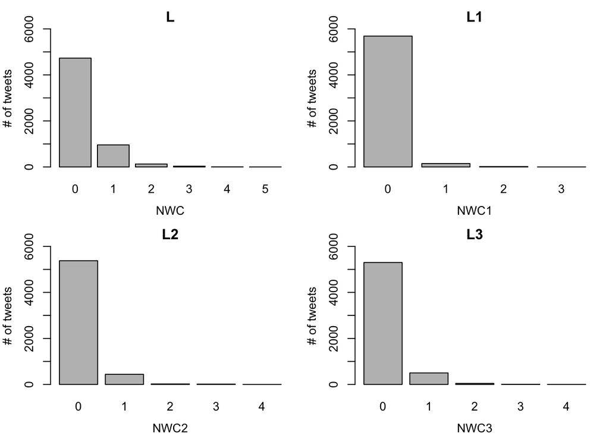

```r
par(mfrow = c(2,2), mar = c(3.5,3.5,2,1))
barplot(table(rowSums(negwordsNum)),
        main = '', xlab = '', ylab = '',
        ylim = c(0, 6000))
title(main = 'L', line = 0.5)
title(xlab = 'NWC', line = 2.5)
title(ylab = '# of tweets', line = 2.5)
for (i in 1:3){
    barplot(table(negwordsNum[,i]),
         main = '', xlab = '', ylab = '',
         ylim = c(0, 6000))
    title(main = paste0('L', i), line = 0.5)
    title(xlab = paste0('NWC',i), line = 2.5)
    title(ylab = '# of tweets', line = 2.5)
}
```

Plot word cloud by frequency of the negative words

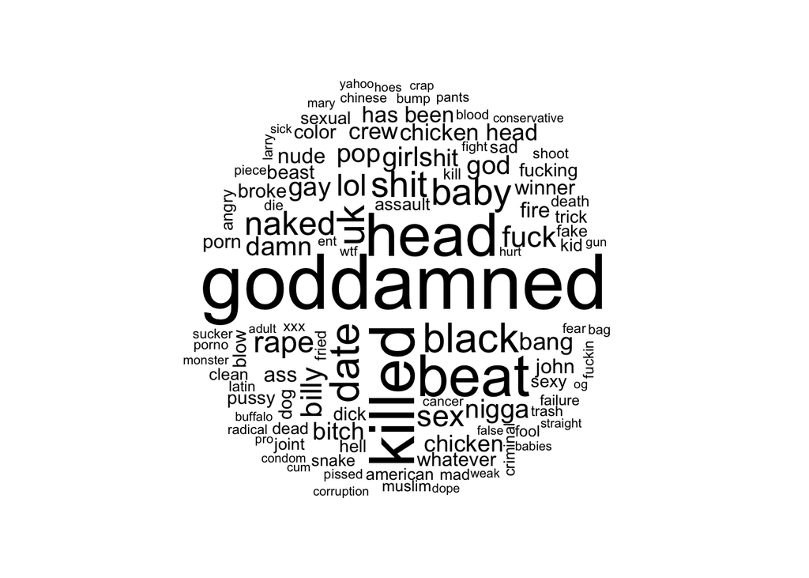

```r
set.seed(5642)
matchwords.tab = table(do.call(c, matchwords))
wordcloud(names(matchwords.tab), as.vector(matchwords.tab), random.order = FALSE)
```

Store the word counts in the data frame.

```r
data.clean$swearNum = negwordsNum[,1] # L1
data.clean$insultNum = negwordsNum[,2] # L2
data.clean$badNum = negwordsNum[,3] # L3
data.clean$negNum = rowSums(negwordsNum)
```

Filter the tweets that contain at least one negative word

```r
data.modelfit = data.clean[rowSums(negwordsNum) > 0,]
data.modelfit = data.modelfit[complete.cases(data.modelfit),]
dim(data.modelfit)
```

```
## [1] 1121   11
```

### 2.2 Logistic regression classification

Before fitting the model, we view the distribution of the user profile variables friends count (FrC), follower count (FoC) and total favorite count (FaC) in the tweets that pass the word frequency screening.

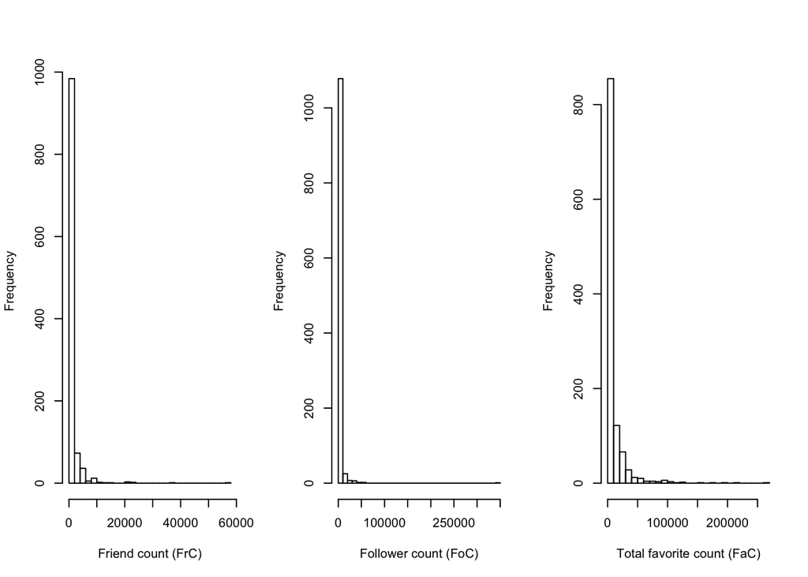

```r
par(mfrow = c(1,3), mar = c(5, 4, 4, 2) + 0.1)
hist(data.modelfit$friendsCount, xlab = 'Friend count (FrC)', main = '', breaks = 30)
hist(data.modelfit$followersCount, xlab = 'Follower count (FoC)', main = '', breaks = 30)
hist(data.modelfit$favoritesCount, xlab = 'Total favorite count (FaC)', main = '', breaks = 30)
```

We have randomly sampled 200 tweets to train logistic model. Now load their indices and manually label them.

```r
logistic.inds = read.table('processed_data/oct_23_logistic_inds_for_manual.txt')[,1]

# Indices of the tweets that are manually labeled as trolls
trollinds.temp = c(1, 2, 5, 8, 16, 18, 24, 29, 31, 37, 38, 40, 43, 45, 46,47, 48, 49, 50, 51,53, 56, 57, 65, 76, 87, 88, 89, 90, 92:97,103, 105, 106, 107, 117,118, 119, 120, 124, 128, 129, 132, 138, 156, 157, 161, 168:170, 171, 172, 173, 175, 192, 199, 200)

data.logit = data.modelfit[logistic.inds,]
data.logit$isTroll = FALSE
data.logit[trollinds.temp, 'isTroll'] = TRUE
```

Fit logistic model for profile variables followersCount, favoritesCount and friendsCount. friendsCount is almost significant under the threshold p-value < 0.1. Use friendsCount the word counts to fit the logistic prediction model.

```r
testmod = glm(isTroll ~ friendsCount,
          data = data.logit, family = binomial)
summary(testmod)
```

```
##
## Call:
## glm(formula = isTroll ~ friendsCount, family = binomial, data = data.logit)
##
## Deviance Residuals:
##     Min       1Q   Median       3Q      Max
## -1.1794  -0.8368  -0.8154   1.5100   1.5979
##
## Coefficients:
##                Estimate Std. Error z value Pr(>|z|)
## (Intercept)  -9.495e-01  1.727e-01  -5.498 3.83e-08 ***
## friendsCount  1.182e-04  7.269e-05   1.626    0.104
## ---
## Signif. codes:  0 '***' 0.001 '**' 0.01 '*' 0.05 '.' 0.1 ' ' 1
##
## (Dispersion parameter for binomial family taken to be 1)
##
##     Null deviance: 246.02  on 199  degrees of freedom
## Residual deviance: 242.99  on 198  degrees of freedom
## AIC: 246.99
##
## Number of Fisher Scoring iterations: 4
```

```r
testmod = glm(isTroll ~ followersCount,
          data = data.logit, family = binomial)
summary(testmod)
```

```
##
## Call:
## glm(formula = isTroll ~ followersCount, family = binomial, data = data.logit)
##
## Deviance Residuals:
##     Min       1Q   Median       3Q      Max
## -1.0412  -0.8426  -0.8318   1.5261   1.5745
##
## Coefficients:
##                  Estimate Std. Error z value Pr(>|z|)
## (Intercept)    -8.980e-01  1.744e-01  -5.148 2.63e-07 ***
## followersCount  5.092e-05  5.459e-05   0.933    0.351
## ---
## Signif. codes:  0 '***' 0.001 '**' 0.01 '*' 0.05 '.' 0.1 ' ' 1
##
## (Dispersion parameter for binomial family taken to be 1)
##
##     Null deviance: 246.02  on 199  degrees of freedom
## Residual deviance: 245.16  on 198  degrees of freedom
## AIC: 249.16
##
## Number of Fisher Scoring iterations: 4
```

```r
testmod = glm(isTroll ~ favoritesCount,
          data = data.logit, family = binomial)
summary(testmod)
```

```
##
## Call:
## glm(formula = isTroll ~ favoritesCount, family = binomial, data = data.logit)
##
## Deviance Residuals:
##     Min       1Q   Median       3Q      Max
## -1.2067  -0.8334  -0.8177   1.4721   1.5878
##
## Coefficients:
##                  Estimate Std. Error z value Pr(>|z|)
## (Intercept)    -9.273e-01  1.811e-01  -5.121 3.04e-07 ***
## favoritesCount  1.050e-05  9.296e-06   1.129    0.259
## ---
## Signif. codes:  0 '***' 0.001 '**' 0.01 '*' 0.05 '.' 0.1 ' ' 1
##
## (Dispersion parameter for binomial family taken to be 1)
##
##     Null deviance: 246.02  on 199  degrees of freedom
## Residual deviance: 244.77  on 198  degrees of freedom
## AIC: 248.77
##
## Number of Fisher Scoring iterations: 4
```

Fit logistic prediction model.

```r
mod = glm(isTroll ~ swearNum + insultNum + badNum + friendsCount,
          data = data.logit, family = binomial)
mod = step(mod, direction = 'backward')
```

```
## Start:  AIC=249.04
## isTroll ~ swearNum + insultNum + badNum + friendsCount
##
##                Df Deviance    AIC
## - badNum        1   239.24 247.24
## - swearNum      1   239.40 247.40
## - insultNum     1   239.99 247.99
## <none>              239.03 249.03
## - friendsCount  1   241.94 249.94
##
## Step:  AIC=247.24
## isTroll ~ swearNum + insultNum + friendsCount
##
##                Df Deviance    AIC
## - swearNum      1   239.43 245.43
## <none>              239.24 247.24
## - friendsCount  1   242.03 248.03
## - insultNum     1   242.34 248.34
##
## Step:  AIC=245.43
## isTroll ~ insultNum + friendsCount
##
##                Df Deviance    AIC
## <none>              239.43 245.43
## - friendsCount  1   242.28 246.28
## - insultNum     1   242.99 246.99
```

```r
print(summary(mod))
```

```
##
## Call:
## glm(formula = isTroll ~ insultNum + friendsCount, family = binomial,
##     data = data.logit)
##
## Deviance Residuals:
##     Min       1Q   Median       3Q      Max
## -1.2420  -0.8958  -0.7379   1.4548   1.9393
##
## Coefficients:
##                Estimate Std. Error z value Pr(>|z|)
## (Intercept)  -7.444e-01  2.021e-01  -3.684 0.000229 ***
## insultNum    -4.932e-01  2.734e-01  -1.804 0.071261 .
## friendsCount  1.181e-04  7.576e-05   1.559 0.118973
## ---
## Signif. codes:  0 '***' 0.001 '**' 0.01 '*' 0.05 '.' 0.1 ' ' 1
##
## (Dispersion parameter for binomial family taken to be 1)
##
##     Null deviance: 246.02  on 199  degrees of freedom
## Residual deviance: 239.43  on 197  degrees of freedom
## AIC: 245.43
##
## Number of Fisher Scoring iterations: 4
```

## 3. Model evaluation

### 3.1 Test data set

Load and proprocess the test data exactly the same was as the training data.

```r
load('raw_data/oct_9_pitt_jolie_tweets.RData')
# Randomly choose 100 as test set
set.seed(65465)
testinds = sample(length(tweets.pitt.jolie), 100, replace = FALSE)
testinds = testinds[order(testinds)]
tweets.pitt.jolie.test = tweets.pitt.jolie[testinds]


namelist.pitt = sapply(tweets.pitt.jolie.test, function(x) x@.xData$screenName)
data.clean.pitt = data.frame(screenName = namelist.pitt)
for (attri in c('text', 'favoriteCount', 'retweetCount')){
    data.clean.pitt[, attri] = sapply(tweets.pitt.jolie.test, function(x) x@.xData[[attri]])
}

load('raw_data/oct_24_pitt_jolie_tweets_user_info.RData')
users.pitt.jolie = unique(users.pitt.jolie)
users.scrnames.pitt.jolie = sapply(users.pitt.jolie, function(x) x@.xData$screenName)
for (attri in c('followersCount', 'favoritesCount', 'friendsCount')){
    data.clean.pitt[, attri] = sapply(data.clean.pitt$screenName,  function(x) ifelse(x %in% users.scrnames.pitt.jolie,
                                                                            users.pitt.jolie[[which(users.scrnames.pitt.jolie == x)]]@.xData[[attri]], NA))
}
```

We also manually labeled troll or non-troll tweets for evaluation.

```r
trollinds.pitt.jolie = c(1, 6, 8, 26, 27,
                         29, 31, 40, 46, 52,
                         56, 64, 65, 66, 68,
                         69, 70, 89)
data.clean.pitt$isTroll = FALSE
data.clean.pitt[trollinds.pitt.jolie, 'isTroll'] = TRUE
```

Calculate word counts.

```r
matchwords.pitt.jolie = vector('list', length = length(tweets.pitt.jolie.test))
for (i in 1:length(tweets.pitt.jolie.test)){
    text = tweets.pitt.jolie.test[[i]]@.xData$text
    if (!is.na(text)){
        text = gsub('.+: ', '', text)
        text = gsub("[^a-zA-Z0-9 ]", '', text)
        text = tolower(paste0(' ', text, ' '))
        matchwords.pitt.jolie[[i]] = negwords[sapply(1:length(negwords), function(x) length(grep(paste0(' ', tolower(negwords[x]), ' '), tolower(text)))>=1)]
    }
}

negwordsNum.pitt.jolie = matrix(nrow = length(matchwords.pitt.jolie), ncol = 3)
for (i in 1:nrow(negwordsNum.pitt.jolie)){
    if (length(matchwords.pitt.jolie[[i]])>0){
        temp = sapply(matchwords.pitt.jolie[[i]], function(x) which(negwords==x))
        negwordsNum.pitt.jolie[i,1] = sum(temp<=length(swear))
        negwordsNum.pitt.jolie[i,2] = sum(temp > length(swear) & temp <= length(c(swear,insult)))
        negwordsNum.pitt.jolie[i,3] = sum(temp > length(c(swear,insult)))
    } else{
        negwordsNum.pitt.jolie[i,] = 0
    }
}

data.clean.pitt$swearNum = negwordsNum.pitt.jolie[,1]
data.clean.pitt$insultNum = negwordsNum.pitt.jolie[,2]
data.clean.pitt$badNum = negwordsNum.pitt.jolie[,3]
data.clean.pitt$negNum = rowSums(negwordsNum.pitt.jolie)
```

### 3.2 Word frequency screening

```r
indices = which(rowSums(negwordsNum.pitt.jolie)>0)
data.clean.pitt.logit = data.clean.pitt[indices,]
```

### 3.3 Logistic regression model prediction

Predict the troll tweets using the logistic model fitted using the training set. The cutoff for predicted probability is 1 - (proportion of troll tweets in 200 randomly selected training tweets). We want to keep the proportion of detected trolls almost the same as that of the training data.

```r
pred.pitt.jolie = predict(mod, data.clean.pitt.logit, type = 'response')
pcutoff = quantile(pred.pitt.jolie, 1 - mean(data.logit$isTroll))
trollinds.pred.pitt = pred.pitt.jolie > pcutoff
```

Print the number of identified troll tweets.

```r
print(sum(trollinds.pred.pitt))
```

```
## [1] 8
```

Print the troll tweets.

```r
data.clean.pitt.logit[trollinds.pred.pitt,'text']
```

```
## [1] "#CelebrityGossip Angelina Jolie Fuming Over Melissa Etheridge’s Divorce Comments — Tells Her To Butt Out https://t.co/SJiwiPJcq3"
## [2] "RT @femaIism: If Angelina Jolie can get over Brad Pitt I can get get over a stupid boy"
## [3] "RT @Advil: with brad pitt and angelina jolie divorcing the last power couple remaining is… mr. salt and mrs. pepper. god bless. https://t.c…"
## [4] "How Tensions Mounted on the Set of Brad Pitt and Angelina Jolie's Movie By the Sea - Yahoo News https://t.co/ttc0VRXZ76"
## [5] "RT @femaIism: If Angelina Jolie can get over Brad Pitt I can get get over a stupid boy"
## [6] "RT @femaIism: If Angelina Jolie can get over Brad Pitt I can get get over a stupid boy"
## [7] "RT @femaIism: If Angelina Jolie can get over Brad Pitt I can get get over a stupid boy"
## [8] "Brad Pitt&amp;#039;s Mom: PISSED at Angelina Jolie! #brad https://t.co/qQxzK5lA8W"
```

```r
# trollinds.pred.pitt are indices within the tweet that passed the word count screening.
# originds gives back the indices of the identified tweets within the test data
originds = indices[trollinds.pred.pitt]
sensitivity = mean(trollinds.pitt.jolie %in% originds)
specificity = 1 - mean(setdiff(1:nrow(data.clean.pitt), trollinds.pitt.jolie) %in% originds)
sens.spec = c(sensitivity, specificity)
names(sens.spec) = c('Sensitivity', 'Specificity')
print(sens.spec)
```

```
## Sensitivity Specificity
##   0.2777778   0.9634146
```

Detected trolls and their category.

```r
trollusers = data.clean.pitt.logit[trollinds.pred.pitt ==TRUE, c('screenName','followersCount')]
trollusers$influentialTroll = ifelse(trollusers$followersCount>819,
                                     'Star', 'Common')
print(trollusers)
```

```
##         screenName followersCount influentialTroll
## 27        bazmi119           1467             Star
## 31  olzanskisrauhl           1221             Star
## 48  helensullivann            811           Common
## 53 AngelinaJolie49           9090             Star
## 57       zorinely_            530           Common
## 68     libbyJones6           1022             Star
## 69       mango_gab           1079             Star
## 89 georgeclony_fan            593           Common
```

```r
# 95th percentile is 819 (https://www.oreilly.com/ideas/tweets-loud-and-quiet)
```